# How to get help for MAGeCKFlute

**Note:** if you use MAGeCKFlute in published research, please cite: Binbin Wang, Mei Wang, Wubing Zhang. “Integrative analysis of pooled CRISPR genetic screens using MAGeCKFlute.” Nature Protocols (2019), doi: [10.1038/s41596-018-0113-7](https://www.nature.com/articles/s41596-018-0113-7).

## How to get help for MAGeCKFlute

Any and all MAGeCKFlute questions should be posted to the **Bioconductor support site**, which serves as a searchable knowledge base of questions and answers:

https://support.bioconductor.org

Posting a question and tagging with “MAGeCKFlute” will automatically send an alert to the package authors to respond on the support site. See the first question in the list of Frequently Asked Questions (FAQ) for information about how to construct an informative post.

You can also email your question to the package authors.

## Input data

### MAGeCK results

MAGeCK [@Wei2014] and MAGeCK-VISPR [@Wei2015] are developed by our lab previously, to analyze CRISPR/Cas9 screen data in different scenarios[@Tim2014, @Hiroko2014, @Ophir2014, @Luke2014, @Silvana2015]. Both algorithms use negative binomial models to model the variances of sgRNAs, and use Robust Rank Aggregation (for MAGeCK) or maximum likelihood framework (for MAGeCK-VISPR) for a robust identification of selected genes.

The command `mageck mle` computes beta scores and the associated statistics for all genes in multiple conditions. The **beta score** describes how the gene is selected: a positive beta score indicates a positive selection, and a negative beta score indicates a negative selection.

The command `mageck test` uses Robust Rank Aggregation (RRA) for robust identification of CRISPR-screen hits, and outputs the summary results at both sgRNA and gene level.

### Customized matrix input

FluteMLE: A matrix contains columns of 'Gene', \code{ctrlname}.beta and \code{treatname}.beta which corresponding to the parameter \code{ctrlname} and \code{treatname}. FluteRRA: A matrix contains columns of “id”, “neg.goodsgrna”, “neg.lfc”, “neg.fdr”, “pos.goodsgrna”, and “pos.fdr”.

## Quick start

Here we show the most basic steps for integrative analysis pipeline. MAGeCKFlute package provides several example data, including `countsummary`, `rra.gene_summary`, `rra.sgrna_summary`, and `mle.gene_summary`, which are generated by running MAGeCK. We will work with them in this document.

```r
library(MAGeCKFlute)
```

**Downstream analysis pipeline for MAGeCK RRA**

```r
##Load gene summary data in MAGeCK RRA results
data("rra.gene_summary")
data("rra.sgrna_summary")
##Run the downstream analysis pipeline for MAGeCK RRA
FluteRRA(rra.gene_summary, rra.sgrna_summary, prefix="RRA", organism="hsa")
```

All pipeline results are written into local directory “./RRA_Flute_Results/”, and all figures are integrated into file “RRA_Flute.rra_summary.pdf”.

**Downstream analysis pipeline for MAGeCK MLE**

```r
## Load gene summary data in MAGeCK MLE results
data("mle.gene_summary")
## Run the downstream analysis pipeline for MAGeCK MLE
FluteMLE(mle.gene_summary, ctrlname="dmso", treatname="plx", prefix="MLE", organism="hsa")
```

All pipeline results are written into local directory “./MLE_Flute_Results/”, and all figures are integrated into file “MLE_Flute.mle_summary.pdf”.

## Section I: Quality control

** Count summary ** `MAGeCK Count` in MAGeCK/MAGeCK-VISPR generates a count summary file, which summarizes some basic QC scores at raw count level, including map ratio, Gini index, and NegSelQC. Use function ‘data’ to load the dataset, and have a look at the file with a text editor to see how it is formatted.

```r
data("countsummary")
head(countsummary)
```

```
##                                   File    Label    Reads   Mapped
## 1 ../data/GSC_0131_Day23_Rep1.fastq.gz day23_r1 62818064 39992777
## 2  ../data/GSC_0131_Day0_Rep2.fastq.gz  day0_r2 47289074 31709075
## 3  ../data/GSC_0131_Day0_Rep1.fastq.gz  day0_r1 51190401 34729858
## 4 ../data/GSC_0131_Day23_Rep2.fastq.gz day23_r2 58686580 37836392
##   Percentage TotalsgRNAs Zerocounts GiniIndex NegSelQC NegSelQCPval
## 1     0.6366       64076         57   0.08510        0            1
## 2     0.6705       64076         17   0.07496        0            1
## 3     0.6784       64076         14   0.07335        0            1
## 4     0.6447       64076         51   0.08587        0            1
##   NegSelQCPvalPermutation NegSelQCPvalPermutationFDR NegSelQCGene
## 1                       1                          1            0
## 2                       1                          1            0
## 3                       1                          1            0
## 4                       1                          1            0
```

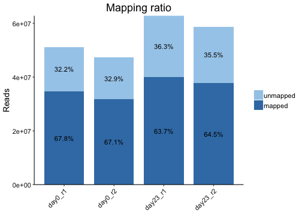

```r
MapRatesView(countsummary)
```

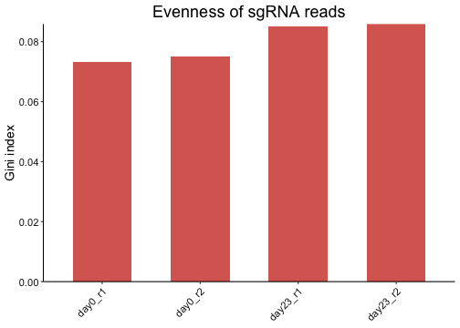

```r
IdentBarView(countsummary, x = "Label", y = "GiniIndex",
             ylab = "Gini index", main = "Evenness of sgRNA reads")
```

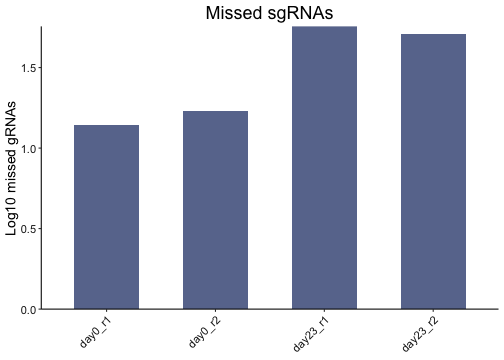

```r
countsummary$Missed = log10(countsummary$Zerocounts)
IdentBarView(countsummary, x = "Label", y = "Missed", fill = "#394E80",
             ylab = "Log10 missed gRNAs", main = "Missed sgRNAs")
```

## Section II: Downstream analysis of MAGeCK RRA

For experiments with two experimental conditions, we recommend using MAGeCK-RRA to identify essential genes from CRISPR/Cas9 knockout screens and tests the statistical significance of each observed change between two states. Gene summary file in MAGeCK-RRA results summarizes the statistical significance of positive selection and negative selection. Use function ‘data’ to load the dataset, and have a look at the file with a text editor to see how it is formatted.

```r
library(MAGeCKFlute)
data("rra.gene_summary")
head(rra.gene_summary)
```

```
##       id num  neg.score neg.p.value  neg.fdr neg.rank neg.goodsgrna
## 1    NF2   4 4.1770e-12  2.9738e-07 0.000275        1             4
## 2 SRSF10   4 4.4530e-11  2.9738e-07 0.000275        2             4
## 3 EIF2B4   8 2.8994e-10  2.9738e-07 0.000275        3             8
## 4  LAS1L   6 1.4561e-09  2.9738e-07 0.000275        4             6
## 5   RPL3  15 2.3072e-09  2.9738e-07 0.000275        5            12
## 6 ATP6V0   7 3.8195e-09  2.9738e-07 0.000275        6             7
##   neg.lfc pos.score pos.p.value pos.fdr pos.rank pos.goodsgrna pos.lfc
## 1 -1.3580   1.00000     1.00000       1    16645             0 -1.3580
## 2 -1.8544   1.00000     1.00000       1    16647             0 -1.8544
## 3 -1.5325   1.00000     1.00000       1    16646             0 -1.5325
## 4 -2.2402   0.99999     0.99999       1    16570             0 -2.2402
## 5 -1.0663   0.95519     0.99205       1    15359             2 -1.0663
## 6 -1.6380   1.00000     1.00000       1    16644             0 -1.6380
```

```r
data(rra.sgrna_summary)
head(rra.sgrna_summary)
```

```
##     sgrna  Gene control_count treatment_count control_mean treat_mean
## 1 s_10963 CDKN2 1175.4/1156.7     4110.7/4046      1166.00    4078.30
## 2 s_10959 CDKN2 651.49/647.25   2188.3/3020.6       649.37    2604.40
## 3 s_36798   NF2    8917/21204   5020.7/5127.9     15061.00    5074.30
## 4 s_45763 RAB6A 3375.8/3667.7   372.88/357.79      3521.80     365.33
## 5 s_23611  GPN1 4043.8/4064.2    767.53/853.7      4054.00     810.61
## 6 s_50164   SF1 3657.8/3352.6   453.62/628.28      3505.20     540.95
##       LFC control_var adj_var  score       p.low p.high  p.twosided
## 1  1.8055  1.7417e+02  4531.0 43.266  1.0000e+00      0  0.0000e+00
## 2  2.0022  8.9814e+00  2365.7 40.195  1.0000e+00      0  0.0000e+00
## 3 -1.5693  7.5491e+07 78871.0 35.559 2.9804e-277      1 5.9609e-277
## 4 -3.2655  4.2617e+04 15519.0 25.338 6.1638e-142      1 1.2328e-141
## 5 -2.3208  2.0966e+02 18159.0 24.069 2.6711e-128      1 5.3423e-128
## 6 -2.6937  4.6575e+04 15438.0 23.857 4.2365e-126      1 8.4731e-126
##           FDR high_in_treatment
## 1  0.0000e+00              True
## 2  0.0000e+00              True
## 3 1.2732e-272             False
## 4 1.9748e-137             False
## 5 6.8462e-124             False
## 6 9.0487e-122             False
```

### Negative selection and positive selection

Then, extract “neg.fdr” and “pos.fdr” from the gene summary table.

```r
dd.rra = ReadRRA(rra.gene_summary)
head(dd.rra)
```

```
##   Official     LFC      FDR
## 1      NF2 -1.3580 0.000275
## 2   SRSF10 -1.8544 0.000275
## 3   EIF2B4 -1.5325 0.000275
## 4    LAS1L -2.2402 0.000275
## 5     RPL3 -1.0663 0.000275
## 6   ATP6V0 -1.6380 0.000275
```

```r
dd.sgrna = ReadsgRRA(rra.sgrna_summary)
```

We provide a function `VolcanoView` to visualize top negative and positive selected genes.

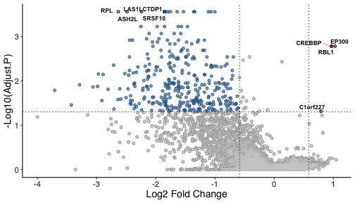

```r
p1 = VolcanoView(dd.rra, x = "LFC", y = "FDR", Label = "Official")
print(p1)
```

We provide a function `RankView` to visualize top negative and positive selected genes.

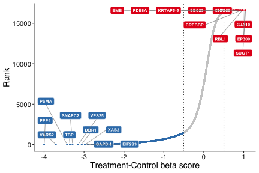

```r
geneList= dd.rra$LFC
names(geneList) = dd.rra$Official
p2 = RankView(geneList, top = 10, bottom = 10)
print(p2)
```

We also provide a function `sgRankView` to visualize the rank of sgRNA targeting top negative and positive selected genes.

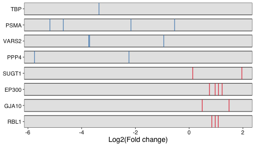

```r
p2 = sgRankView(dd.sgrna, top = 4, bottom = 4)
print(p2)
```

Select negative selection and positive selection genes and perform enrichment analysis.

#### Enrichment analysis

```r
universe = dd.rra$Official
geneList= dd.rra$LFC
names(geneList) = universe
enrich = EnrichAnalyzer(geneList = geneList, keytype = "Symbol",
                        method = "GSEA", type = "GOMF+GOCC+GOBP",
                        limit = c(1, 80))
```

Visualize the top enriched genes and pathways/GO terms using `EnrichedGeneView` and `EnrichedView`.

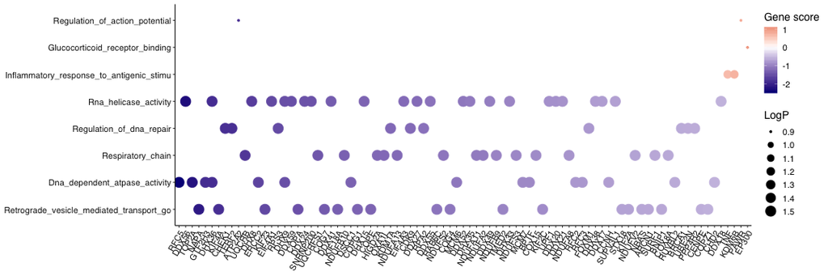

```r
EnrichedGeneView(slot(enrich, "result"), geneList, keytype = "Symbol")
```

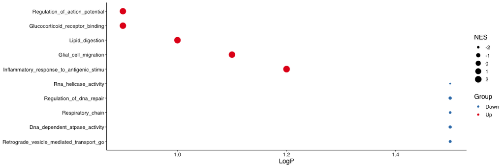

```r
EnrichedView(slot(enrich, "result"))
```

Simplify the enrichment results using `EnrichedFilter`.

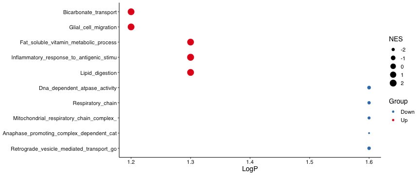

```r
enrich = EnrichAnalyzer(geneList = geneList, keytype = "Symbol",
                        method = "GSEA", type = "GOMF+GOCC+GOBP",
                        limit = c(2, 80), filter = FALSE)
enrich2 = EnrichedFilter(enrich)
EnrichedView(enrich2)
```

## Section III: Downstream analysis of MAGeCK MLE

** Gene summary ** The gene summary file in MAGeCK-MLE results includes beta scores of all genes in multiple condition samples.

```r
library(MAGeCKFlute)
data("mle.gene_summary")
head(mle.gene_summary)
```

```
##     Gene sgRNA dmso.beta   dmso.z dmso.p.value dmso.fdr dmso.wald.p.value
## 1   FEZ1     6 -0.045088 -0.66798      0.79649  0.97939        5.0415e-01
## 2    TNN     6  0.094325  1.36120      0.34176  0.89452        1.7344e-01
## 3  NAT8L     3  0.026362  0.24661      0.54185  0.94568        8.0521e-01
## 4   OAS2     8 -0.271210 -4.76860      0.46995  0.93572        1.8555e-06
## 5 OR10H3     2 -0.098324 -0.86408      0.99473  0.99872        3.8754e-01
## 6  CCL16     3 -0.309750 -3.43910      0.38495  0.90896        5.8372e-04
##   dmso.wald.fdr  plx.beta    plx.z plx.p.value plx.fdr plx.wald.p.value
## 1    6.3060e-01 -0.036721 -0.54346     0.81604 0.98345       5.8681e-01
## 2    2.8578e-01  0.065533  0.94344     0.47309 0.93207       3.4546e-01
## 3    8.7248e-01  0.044979  0.42072     0.53600 0.94583       6.7396e-01
## 4    1.4126e-05 -0.289010 -5.07170     0.40411 0.90933       3.9431e-07
## 5    5.2094e-01 -0.365730 -3.16890     0.26493 0.85892       1.5300e-03
## 6    2.4781e-03 -0.148830 -1.66090     0.78757 0.98229       9.6739e-02
##   plx.wald.fdr
## 1   6.9940e-01
## 2   4.7400e-01
## 3   7.7008e-01
## 4   3.5296e-06
## 5   5.4996e-03
## 6   1.7459e-01
```

Then, extract beta scores of control and treatment samples from the gene summary table(can be a file path of 'gene_summary' or data frame).

```r
data("mle.gene_summary")
ctrlname = c("dmso")
treatname = c("plx")
#Read beta scores from gene summary table in MAGeCK MLE results
dd=ReadBeta(mle.gene_summary)
head(dd)
```

```
##     Gene      dmso       plx
## 1   FEZ1 -0.045088 -0.036721
## 2    TNN  0.094325  0.065533
## 3  NAT8L  0.026362  0.044979
## 4   OAS2 -0.271210 -0.289010
## 5 OR10H3 -0.098324 -0.365730
## 6  CCL16 -0.309750 -0.148830
```

### Batch effect removal

Is there batch effects? This is a commonly asked question before perform later analysis. In our package, we provide `HeatmapView` to ensure whether the batch effect exists in data and use `BatchRemove` to remove easily if same batch samples cluster together.

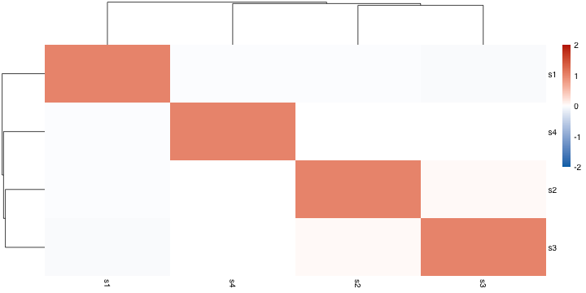

```r
##Before batch removal
edata = matrix(c(rnorm(2000, 5), rnorm(2000, 8)), 1000)
colnames(edata) = paste0("s", 1:4)
HeatmapView(cor(edata))
```

```r
## After batch removal
batchMat = data.frame(sample = colnames(edata), batch = rep(1:2, each = 2))
edata1 = BatchRemove(edata, batchMat)
```

```
## Standardizing Data across genes
```

```r
head(edata1$data)
```

```
##            s1       s2       s3       s4
## [1,] 5.797253 6.309288 6.534965 5.597783
## [2,] 6.688960 5.980787 5.696982 6.968080
## [3,] 5.870633 7.125978 6.673296 6.263478
## [4,] 7.365095 6.332746 7.374763 6.255741
## [5,] 6.617444 6.756784 6.542969 6.878130
## [6,] 6.114756 5.175577 5.481561 5.829241
```

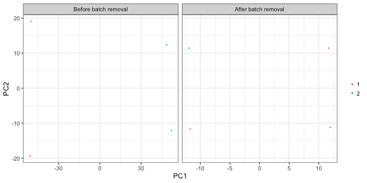

```r
print(edata1$p)
```

### Normalization of beta scores

It is difficult to control all samples with a consistent cell cycle in a CRISPR screen experiment with multi conditions. Besides, beta score among different states with an inconsistent cell cycle is incomparable. So it is necessary to do the normalization when comparing the beta scores in different conditions. Essential genes are those genes that are indispensable for its survival. The effect generated by knocking out these genes in different cell types is consistent. Based on this, we developed the cell cycle normalization method to shorten the gap of the cell cycle in different conditions. Besides, a previous normalization method called loess normalization is available in this package.[@Laurent2004]

```r
dd_essential = NormalizeBeta(dd, samples=c(ctrlname, treatname), method="cell_cycle")
head(dd_essential)
```

```
##     Gene        dmso         plx
## 1   FEZ1 -0.05193303 -0.04904667
## 2    TNN  0.10864495  0.08752963
## 3  NAT8L  0.03036415  0.06007653
## 4   OAS2 -0.31238374 -0.38601834
## 5 OR10H3 -0.11325106 -0.48848997
## 6  CCL16 -0.35677469 -0.19878589
```

```r
#OR
dd_loess = NormalizeBeta(dd, samples=c(ctrlname, treatname), method="loess")
head(dd_loess)
```

```
##     Gene        dmso         plx
## 1   FEZ1 -0.04237199 -0.03943701
## 2    TNN  0.10089455  0.05896345
## 3  NAT8L  0.03119839  0.04014261
## 4   OAS2 -0.26848960 -0.29173040
## 5 OR10H3 -0.09620861 -0.36784539
## 6  CCL16 -0.30767648 -0.15090352
```

#### Distribution of all gene beta scores

After normalization, the distribution of beta scores in different conditions should be similar. We can evaluate the distribution of beta scores using the function ‘ViolinView’, ‘DensityView’, and ‘DensityDiffView’.

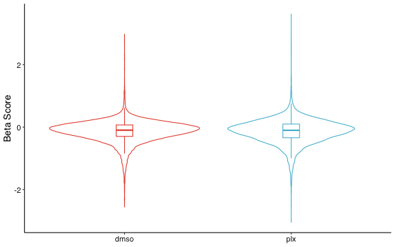

```r
ViolinView(dd_essential, samples=c(ctrlname, treatname))
```

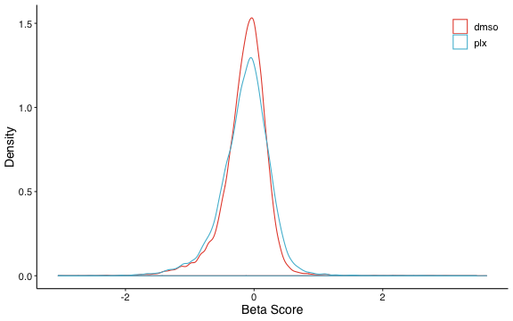

```r
DensityView(dd_essential, samples=c(ctrlname, treatname))
```

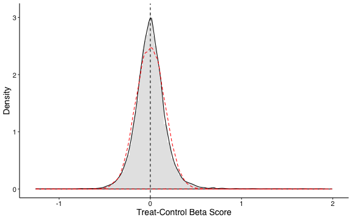

```r
DensityDiffView(dd_essential, ctrlname, treatname)
```

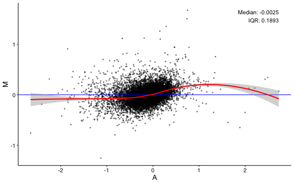

```r
#we can also use the function 'MAView' to evaluate the data quality of normalized
#beta score profile.
MAView(dd_essential, ctrlname, treatname)
```

### Estimate cell cycle time by linear fitting

After normalization, the cell cycle time in different condition should be almost consistent. Here we use a linear fitting to estimate the cell cycle time, and use function `CellCycleView` to view the cell cycle time of all samples.

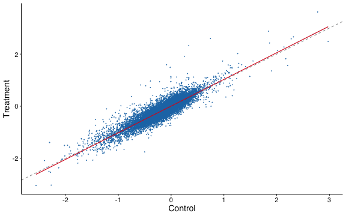

```r
##Fitting beta score of all genes
CellCycleView(dd_essential, ctrlname, treatname)
```

### Positive selection and negative selection

The function `ScatterView` can group all genes into three groups, positive selection genes (GroupA), negative selection genes (GroupB), and others, and visualize these three grouped genes in scatter plot. We can also use function `RankView` to rank the beta score deviation between control and treatment and mark top selected genes in the figure.

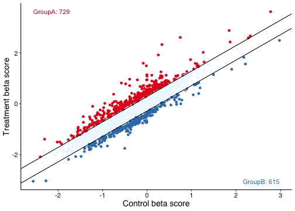

```r
p1 = ScatterView(dd_essential, ctrlname, treatname)
print(p1)
```

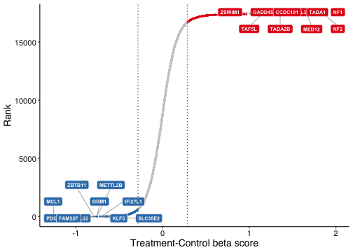

```r
## Add column of 'diff'
dd_essential$Control = rowMeans(dd_essential[,ctrlname, drop = FALSE])
dd_essential$Treatment = rowMeans(dd_essential[,treatname, drop = FALSE])

rankdata = dd_essential$Treatment - dd_essential$Control
names(rankdata) = dd_essential$Gene
p2 = RankView(rankdata)
print(p2)
```

### Functional analysis of selected genes

For gene set enrichment analysis, we provide three methods in this package, including “ORT”(Over-Representing Test [@Guangchuang2012]), “GSEA”(Gene Set Enrichment Analysis [@Aravind2005]), and “HGT”(hypergeometric test), which can be performed on annotations of Gene ontology(GO) terms [@GO2014], Kyoto encyclopedia of genes and genomes (KEGG) pathways [@Minoru2014], MsigDB gene sets, or custom gene sets. The enrichment analysis can be done easily using function `EnrichAnalyzer`, which returns an enrichResult instance. Alternatively, you can do enrichment analysis using the function `enrich.ORT` for “ORT”, `enrich.GSE` for GSEA, and `enrich.HGT` for “HGT”. Function `EnrichedView` can be used to generate `gridPlot` from `enrichRes` easily, as shown below.

```r
## Get information of positive and negative selection genes
groupAB = p1$data
geneList = groupAB$diff; names(geneList) = groupAB$Gene
## Do enrichment analysis for positive selection genes.
idx1 = groupAB$group=="up"
hgtA = EnrichAnalyzer(geneList[idx1], keytype = "Symbol", method = "HGT",
                      universe = groupAB$Gene)
hgtA_grid = EnrichedView(slot(hgtA, "result"))

## look at the results
head(slot(hgtA, "result"))
```

```
##                    ID
## CORUM_320   CORUM_320
## CORUM_6664 CORUM_6664
## CORUM_230   CORUM_230
## CORUM_3061 CORUM_3061
## CORUM_6888 CORUM_6888
## CORUM_207   CORUM_207
##                                                                                              Description
## CORUM_320                                                                    55s ribosome, mitochondrial
## CORUM_6664                                                                    Staga complex, spt3-linked
## CORUM_230                                                                               Mediator complex
## CORUM_3061 Rna polymerase ii complex (cbp, pcaf, rpb1, baf47, cycc, cdk8), chromatin structure modifying
## CORUM_6888                                                     V-atpase-ragulator-axin/lkb1-ampk complex
## CORUM_207                                           Ubiquitin e3 ligase (asb2, tceb1, tceb2, cul5, rnf7)
##                  NES       pvalue     p.adjust GeneRatio BgRatio
## CORUM_320  2.4051518 1.233943e-10 8.020626e-09     18/74   74/78
## CORUM_6664 3.5427573 2.347482e-08 7.629315e-07      8/19   19/19
## CORUM_230  2.4745618 4.273903e-07 9.260124e-06      9/32   32/32
## CORUM_3061 1.3128903 7.289144e-07 1.184486e-05       4/6     6/6
## CORUM_6888 0.8300731 1.175458e-05 1.528096e-04      5/14   14/14
## CORUM_207  1.2275716 1.463146e-05 1.585075e-04       3/5     5/5
##                                                                                                                 geneID
## CORUM_320  63931/54148/6182/63875/29093/65080/116541/6183/28957/51021/51073/51650/28998/51116/54948/28973/64979/116540
## CORUM_6664                                                             6314/10629/10474/117143/27097/6883/112869/93624
## CORUM_230                                                              9969/219541/10025/51586/892/9862/9439/1024/9968
## CORUM_3061                                                                                          6598/892/1024/1387
## CORUM_6888                                                                                389541/10542/9114/55004/8649
## CORUM_207                                                                                               9616/6923/8065
##                                                                                                                                geneName
## CORUM_320  MRPS14/MRPL39/MRPL12/MRPL17/MRPL22/MRPL44/MRPL54/MRPS12/MRPS28/MRPS16/MRPL4/MRPS33/MRPL13/MRPS2/MRPL16/MRPS18B/MRPL36/MRPL53
## CORUM_6664                                                                           ATXN7/TAF6L/TADA3/TADA1/TAF5L/TAF12/CCDC101/TADA2B
## CORUM_230                                                                           MED13/MED19/MED16/MED15/CCNC/MED24/MED23/CDK8/MED12
## CORUM_3061                                                                                                     SMARCB1/CCNC/CDK8/CREBBP
## CORUM_6888                                                                                       C7orf59/HBXIP/ATP6V0D1/LAMTOR1/LAMTOR3
## CORUM_207                                                                                                               RNF7/TCEB2/CUL5
##            Count
## CORUM_320     18
## CORUM_6664     8
## CORUM_230      9
## CORUM_3061     4
## CORUM_6888     5
## CORUM_207      3
```

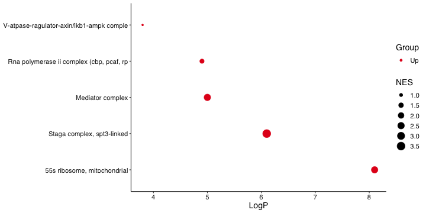

```r
print(hgtA_grid)
```

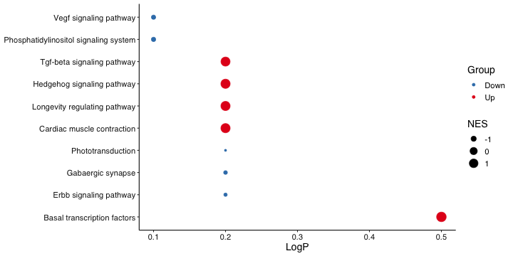

```r
## Do enrichment analysis using GSEA method
gseA = EnrichAnalyzer(geneList, keytype = "Symbol", method = "GSEA", type = "KEGG",
                      limit = c(2, 100), pvalueCutoff = 1)
gseA_grid = EnrichedView(gseA)
print(gseA_grid)
```

For enriched KEGG pathways, we can use function `KeggPathwayView` to visualize the beta score level in control and treatment on pathway map.[@Weijun2013]

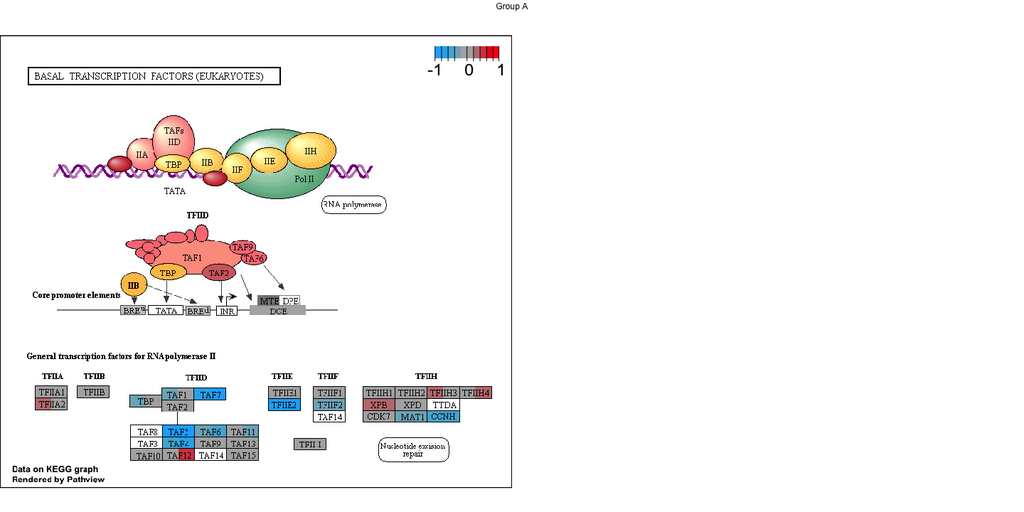

```r
genedata = dd_essential[,c("Control","Treatment")]
keggID = gsub("KEGG_", "", slot(gseA, "result")$ID[1])
arrangePathview(genedata, pathways = keggID, organism = "hsa", sub = NULL)
```

### Identify treatment-associated genes using 9-square model

We developed a 9-square model, which group all genes into several subgroups by considering the selection status of genes in control and treatment. Each subgroup genes correspond to specific functions.

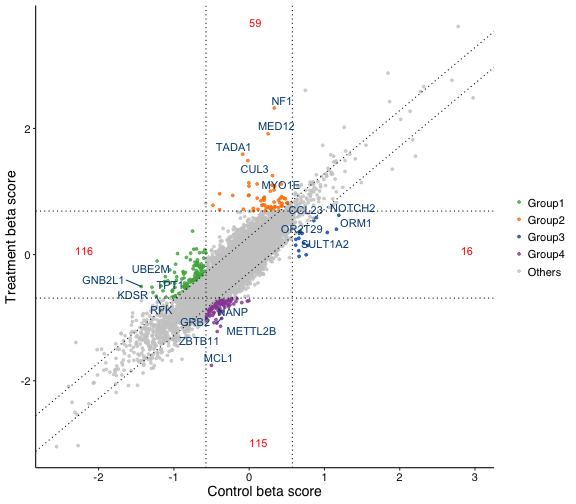

```r
p3 = SquareView(dd_essential, label = "Gene",
                x_cutoff = CutoffCalling(dd_essential$Control, 2),
                y_cutoff = CutoffCalling(dd_essential$Treatment, 2))
print(p3)
```

### Functional analysis for treatment-associated genes

Same as the section above. We can do enrichment analysis for treatment-associated genes.

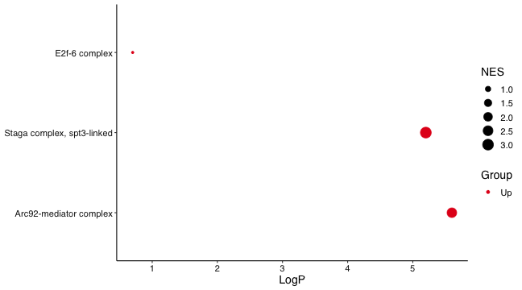

```r
#Get 9-square groups
Square9 = p3$data
idx=Square9$group=="topcenter"
geneList = (Square9$y - Square9$x)[idx]
names(geneList) = Square9$Gene[idx]
universe = Square9$Gene
# Enrichment analysis
kegg1 = EnrichAnalyzer(geneList = geneList, keytype = "Symbol", universe = universe)
EnrichedView(kegg1, top = 10, bottom = 0)
```

Also, pathway visualization can be done using function `KeggPathwayView`, the same as the section above.

```r
genedata = dd_essential[, c("Control","Treatment")]
arrangePathview(genedata, pathways = "hsa01521", organism = "hsa", sub = NULL)
```

# References

Subramanian, A. et al. Gene set enrichment analysis: a knowledge-based approach for interpreting genome-wide expression profiles. Proc. Natl. Acad. Sci. USA 102, [15545–15550](https://www.pnas.org/content/102/43/15545) (2005).

Yu, G., Lg, W., H., Y. & Qy., H. clusterProfiler: an R package for comparing biological themes among gene clusters. OMICS 16, [284–287](https://www.liebertpub.com/doi/10.1089/omi.2011.0118) (2012).

Luo, W. & Brouwer, C. Pathview: an R/Bioconductor package for pathway-based data integration and visualization. Bioinformatics 29, [1830–1831](https://academic.oup.com/bioinformatics/article-abstract/29/14/1830/232698) (2013).